# Connecting all modules

AGRON 5130 - Module 14

Caio dos Santos

2026-05-03

# Introduction

Before we start, let me be really clear about what this module is and what it is not.

We are not learning a brand-new method here.

This is an integration module.

From Modules 00 to 13, we built statistical reasoning step by step: we started with R and data structures, moved through probability, sampling, hypothesis testing, ANOVA, regression, spatial data, and machine learning. In this final lecture, we connect those pieces into one decision workflow that mirrors how agronomic analysis actually happens in practice.

That is the whole point of Module 14.

# Introduction

I like to think of this lecture as a field-to-decision map.

When real data arrive, we usually do not start by asking, “Which test do I run?” We start by asking a different question first:

> What is the agronomic question, what kind of data do I have, and which method gives me an answer that is both statistically valid and biologically meaningful?

That sentence summarizes the entire course.

In Modules 00 and 01, we learned the mechanics: projects, paths, scripts, data frames, indexing, and reproducible workflows. From Module 02 onward, we layered on inference and modeling tools. Now, in Module 14, we connect all of that around common agronomic scenarios.

Across all modules, the workflow stayed surprisingly consistent:

1. Define the agronomic question.
2. Understand the data-generating process.
3. Match method to design and data structure.
4. Diagnose assumptions and limitations.
5. Interpret results biologically, not just statistically.

# Scenario 1: Field Yield Distribution (Population Summary and Z-Distribution)

Suppose you receive a cleaned yield monitor dataset from one field and your first goal is descriptive: summarize the population behavior and understand distribution shape.

This takes us right back to:

- Module 01: data loading and structure checks
- Module 02: probability and normal distribution intuition

What we do first:

1. Inspect distribution shape (symmetry, skewness, tails).
2. Estimate center and spread (mean, standard deviation).
3. Ask whether a normal approximation is reasonable for quick probability statements.

If the data are approximately normal, z-scores give a fast way to talk about relative position (for example, values above one standard deviation from the mean). This is useful for screening and contextual interpretation, but at this stage we are still describing data, not testing treatment effects.

So the first question is simple: what does this field look like before we even think about formal inference?

One important reminder: normality is not a universal requirement for all statistics. It is a modeling approximation that can be useful in some contexts and unnecessary in others.

```r
barley <- read.csv("data/barley_uniformity.csv")

head(barley)
```

```
##   row col yield
## 1  20   1   185
## 2  19   1   169
## 3  18   1   216
## 4  17   1   165
## 5  16   1   133
## 6  15   1   195
```

```r
summary(barley$yield)
```

```
##    Min. 1st Qu.  Median    Mean 3rd Qu.    Max.
##    22.0   130.0   155.0   151.9   174.0   248.0
```

Before computing anything formal, I like to inspect the distribution shape directly.

When you look at this histogram, ask yourself: would a normal approximation be wildly wrong here, or reasonable for a first pass?

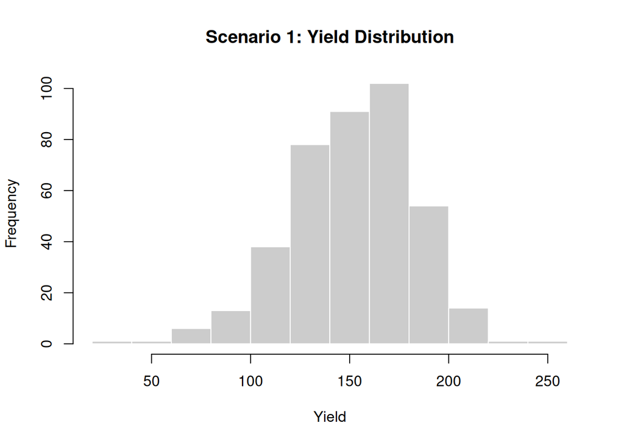

```r
hist(barley$yield,
  col = "grey80",
  border = "white",
  main = "Scenario 1: Yield Distribution",
  xlab = "Yield")
```

Now we can calculate center and spread, then make one probability statement under a normal approximation.

This gives us a fast baseline that helps with scouting thresholds and communication with growers.

```r
yield_mean <- mean(barley$yield)
yield_sd   <- sd(barley$yield)

yield_mean
```

```
## [1] 151.92
```

```r
yield_sd
```

```
## [1] 31.14029
```

```r
z_threshold <- yield_mean + yield_sd
z_threshold
```

```
## [1] 183.0603
```

```r
prob_above_threshold <- 1 - pnorm(z_threshold,
                                  mean = yield_mean,
                                  sd = yield_sd)
prob_above_threshold
```

```
## [1] 0.1586553
```

At this point, we have a descriptive anchor. Now we shift to what we usually face in practice: estimation from a sample, not from a full population.

# Scenario 2: Yield Estimate (Sampling t-Distribution)

Now imagine we cannot measure every unit in the field and must estimate population yield from a sample.

This is the real world of agronomy, right?

Field work is expensive and measurements take time.

This takes us right back to:

- Module 03: sampling variability, standard error, and confidence intervals

The key shift is conceptual: we move from known population summaries to uncertainty-aware estimates.

In other words, we are no longer describing everything we observed. We are inferring what is plausible in the larger population.

When population standard deviation is unknown (the usual case in agronomy), inference uses the $t$-distribution, not the z-distribution. This is where the standard error becomes central:

$$SE = \frac{s}{\sqrt{n}}$$

This scenario is the bridge between “describing what I observed” and “inferring what is plausible in the population.”

```r
yield_sample <- sample(barley$yield, size = 20)
```

[output not shown]

Once the sample is drawn, we move to the $t$ framework for interval estimation.

The key insight is that uncertainty is part of the estimate, not an optional appendix.

As you read the output, focus less on the exact endpoints and more on the width: wide intervals mean limited precision for management decisions.

```r
t_value <- qt(0.975, df = 19)
sample_mean <- mean(yield_sample)
sample_sd <- sd(yield_sample)
se <- sample_sd / sqrt(20)

ci_95 <- sample_mean + c(-1, 1) * t_value * se

ci_95
```

```
## [1] 147.5368 174.0632
```

If this interval were too wide for a decision, the practical response is not to force certainty. The practical response is to improve design, increase sample size, or collect more informative data.

Notice how this interval is not a statement about individual plants. It is a statement about plausible values for the population mean yield.

Now notice what changed as we move to the next scenario. In Scenario 2, uncertainty came from estimating one population mean. In Scenario 3, uncertainty comes from comparing competing treatments. The machinery changes, but the logic does not: estimate signal while accounting for variability.

# Scenario 3: Side-By-Side (t-Test)

Suppose the question is comparative: did treatment A differ from treatment B?

This scenario connects directly to:

- Module 04: two-treatment comparisons and paired logic
- Module 05: hypotheses and the linear additive model foundation

The first move is to formalize the question as hypotheses. Then we pick the test structure that matches design:

- independent groups when units are unrelated
- paired comparison when units are naturally matched (for example, strip trials in the same field zone)

The goal is not to chase a p-value. The goal is to quantify evidence, report uncertainty, and interpret effect size in agronomic language.

So in this first step, we organize the two treatment vectors into a paired structure. I like showing this explicitly because students can see exactly where each column in the test comes from.

```r
corn_starter <- read.csv("data/corn_starter.csv")
head(corn_starter)
```

```
##   block plot treatment yield
## 1     1   11   Starter 193.4
## 2     1   12   Control 194.2
## 3     2   21   Starter 192.2
## 4     2   22   Control 189.0
## 5     3   31   Control 193.8
## 6     3   32   Starter 194.2
```

```r
treatment_levels <- unique(corn_starter$treatment)

yield_trt_a <- corn_starter$yield[
  corn_starter$treatment == treatment_levels[1]
]
yield_trt_b <- corn_starter$yield[
  corn_starter$treatment == treatment_levels[2]
]

paired_data <- data.frame(yield_a = yield_trt_a,
                          yield_b = yield_trt_b)

paired_data
```

```
##    yield_a yield_b
## 1    193.4   194.2
## 2    192.2   189.0
## 3    194.2   193.8
## 4    190.5   186.4
## 5    198.7   196.4
## 6    193.4   189.8
## 7    196.0   187.6
## 8    196.7   185.3
## 9    201.5   184.5
## 10   198.9   192.6
```

I usually pause here and compare groups visually before running the formal test.

Notice how this protects us from chasing p-values without looking at the data pattern first.

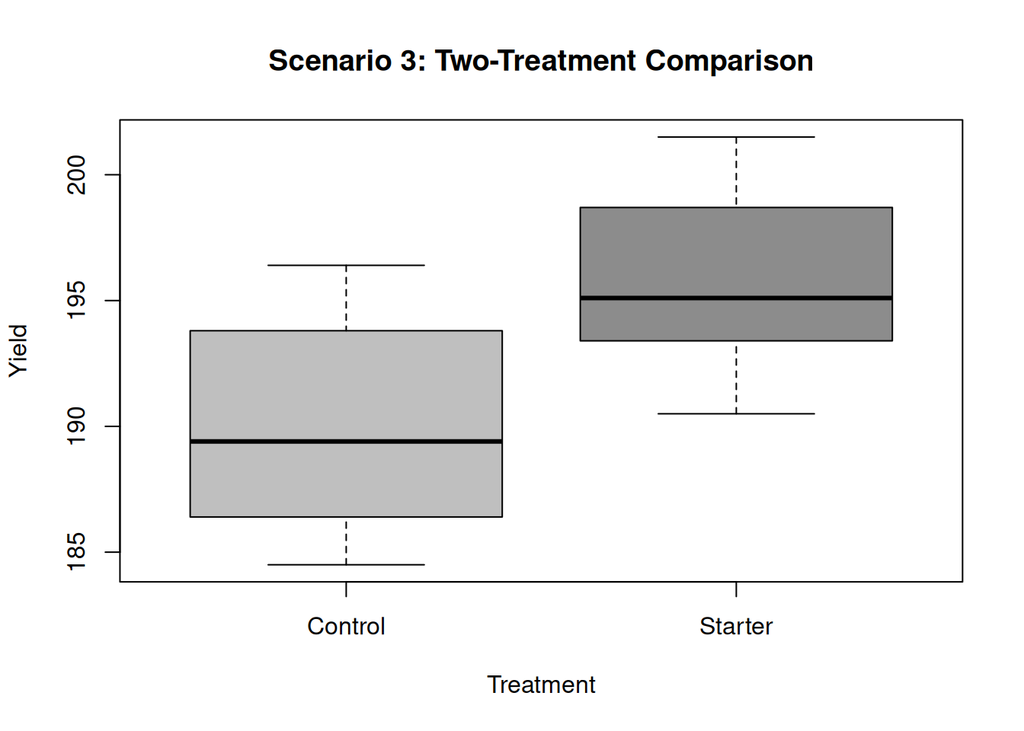

```r
boxplot(corn_starter$yield ~ corn_starter$treatment,
  col = c("grey75", "grey55"),
  xlab = "Treatment",
  ylab = "Yield",
  main = "Scenario 3: Two-Treatment Comparison")
```

Then we run the paired test and focus on estimate plus uncertainty.

This means effect size and interval are front and center in the interpretation.

Before you even read the p-value, ask: is the observed difference large enough to matter agronomically?

And this is where agronomic judgment matters: a statistically detectable difference can still be agronomically trivial.

```r
t.test(paired_data$yield_a,
  paired_data$yield_b,
       paired = TRUE)
```

```
##
##  Paired t-test
##
## data:  paired_data$yield_a and paired_data$yield_b
## t = 3.2711, df = 9, p-value = 0.009665
## alternative hypothesis: true mean difference is not equal to 0
## 95 percent confidence interval:
##  1.724211 9.455789
## sample estimates:
## mean difference
##            5.59
```

# Scenario 4: Multiple-Treatment Trial (ANOVA in RCBD)

Now expand from two treatments to many treatments.

This is exactly where repeated $t$-tests stop being a good strategy.

This takes us back to:

- Module 06: ANOVA for multiple-treatment trials
- Module 07: experimental design logic (especially RCBD)
- Module 08: means separation and communication of results

Once we have multiple treatments, repeated $t$-tests are no longer a good strategy. ANOVA gives one coherent framework to compare treatment variation against residual variation.

If field heterogeneity is important, RCBD is usually preferable to CRD because blocking absorbs known spatial variation before it inflates error. After a significant ANOVA, we move to means separation and report results transparently with tables/figures and clear group interpretation.

> **Key insight: design and analysis are inseparable.**

Before plotting or modeling, we make sure block and treatment are stored as factors. That simple data-type decision controls how R interprets the design.

```r
rcbd <- read.csv("data/rcbd-data.csv")
```

A quick plot gives us context before the ANOVA table.

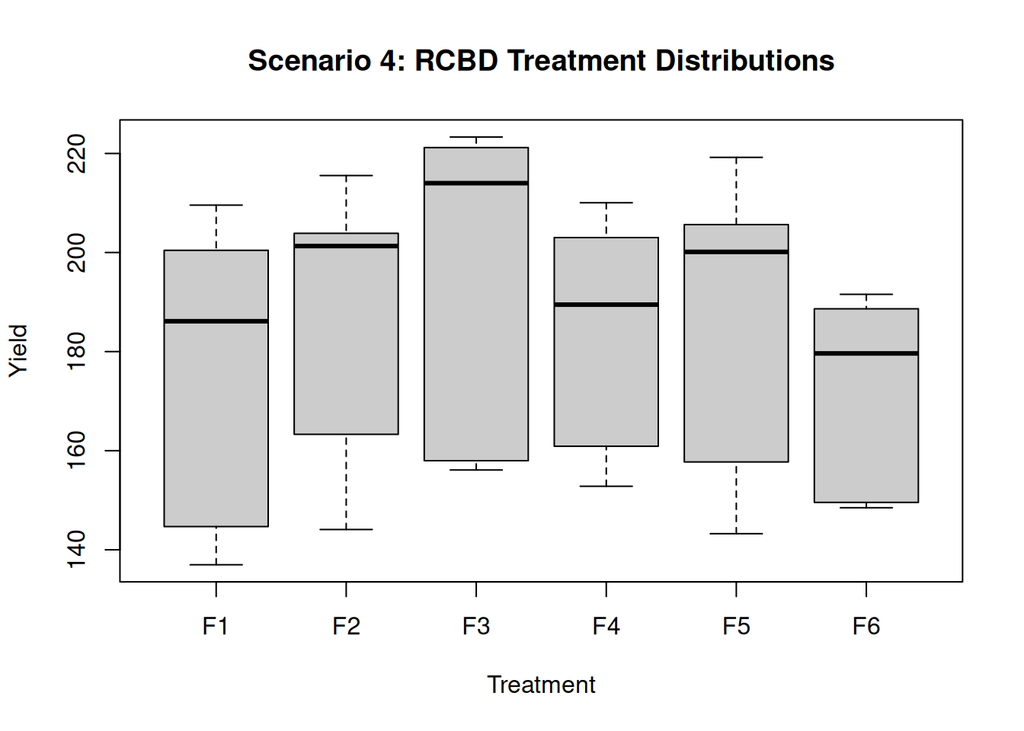

```r
boxplot(yield ~ trt,
  data = rcbd,
  col = "grey80",
  xlab = "Treatment",
  ylab = "Yield",
  main = "Scenario 4: RCBD Treatment Distributions")
```

Now we fit the blocked model and inspect treatment means.

Notice what we are doing: we are separating treatment variation from block-to-block variation before drawing conclusions.

```r
model_rcbd <- aov(yield ~ block + trt, data = rcbd)
summary(model_rcbd)
```

```
##             Df Sum Sq Mean Sq F value   Pr(>F)
## block        4  19937    4984  67.368 2.56e-11 ***
## trt          5   1647     329   4.453  0.00688 **
## Residuals   20   1480      74
## ---
## Signif. codes:  0 '***' 0.001 '**' 0.01 '*' 0.05 '.' 0.1 ' ' 1
```

```r
anova(model_rcbd)
```

```
## Analysis of Variance Table
##
## Response: yield
##           Df  Sum Sq Mean Sq F value    Pr(>F)
## block      4 19937.3  4984.3  67.368 2.555e-11 ***
## trt        5  1647.3   329.5   4.453  0.006882 **
## Residuals 20  1479.7    74.0
## ---
## Signif. codes:  0 '***' 0.001 '**' 0.01 '*' 0.05 '.' 0.1 ' ' 1
```

```r
model.tables(model_rcbd, type = "means")
```

```
## Tables of means
## Grand mean
##
## 182.6192
##
##  block
## block
##      1      2      3      4      5
## 152.75 149.90 206.93 197.53 205.99
##
##  trt
## trt
##     F1     F2     F3     F4     F5     F6
## 175.56 185.62 194.52 183.25 185.19 171.58
```

Interpretation checkpoint: if ANOVA does not show evidence of treatment differences, we should be careful about jumping into means separation. If ANOVA is significant, then post-hoc comparisons become meaningful.

# Scenario 5: Cover Crop Species x Termination (Split-Plot ANOVA)

Suppose we need to evaluate more than one factor at once, such as hybrid and fungicide, or species and termination method.

This is where interactions become the main story.

This takes us back to:

- Module 07: factorial and split-plot design structures
- Module 08: post-ANOVA interpretation strategy

At this point, interactions become central.

In practice, this is usually where interpretation gets harder and more interesting.

The practical sequence is:

1. Check interaction first.
2. If interaction is important, interpret simple effects instead of only main effects.
3. Align interpretation with design structure (whole-plot vs subplot error terms in split-plot settings).

This is where design and analysis are inseparable: if design structure is ignored, the test is not just inefficient, it can be wrong.

So first we define each role in the design clearly: block, whole-plot unit, species, and termination. Once those are encoded correctly, the model can use the right error strata.

```r
split_dat <- read.csv("data/cover-crop-and-termination-split.csv")
```

For factorial logic, I prefer to look at interaction shape first.

If lines diverge or cross, we already know a main-effect-only story is probably incomplete.

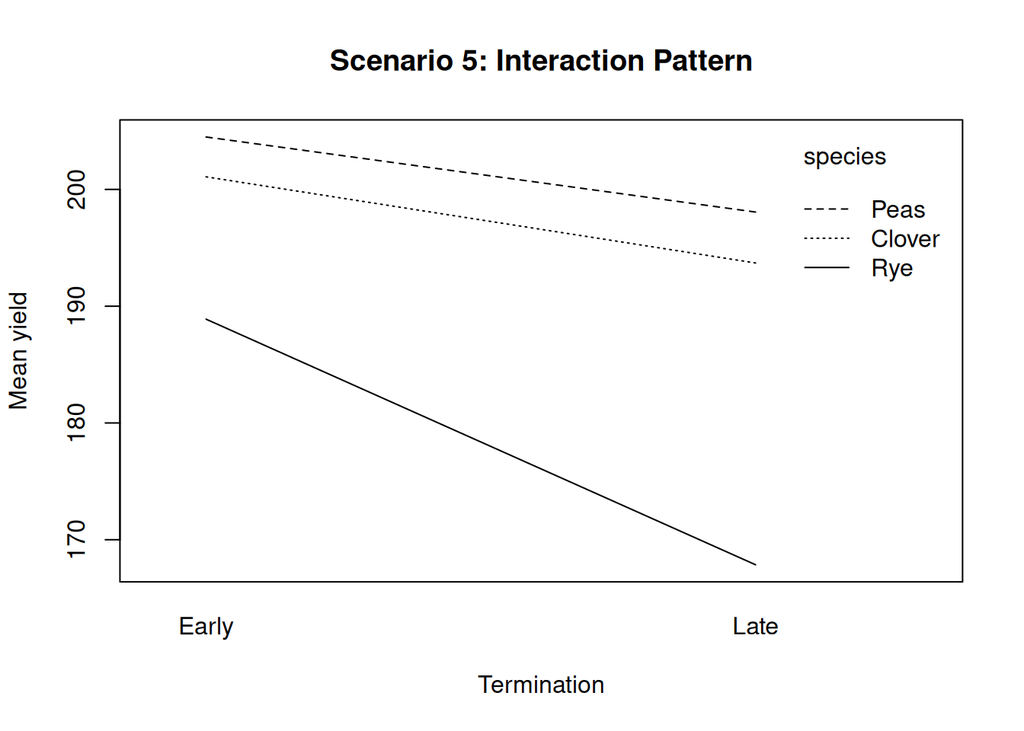

```r
with(split_dat,
  interaction.plot(x.factor = termination,
          trace.factor = species,
          response = yield,
          xlab = "Termination",
          ylab = "Mean yield",
          main = "Scenario 5: Interaction Pattern"))
```

Then we fit the model that respects the split-plot structure.

In other words, we let the design dictate the error structure.

Factorial structure determines which biological questions we can ask. Split-plot structure determines which variability should be used to test those questions.

```r
model_split <- aov(yield ~ species * termination + Error(block / main_plot),
                   data = split_dat)

summary(model_split)
```

```
##
## Error: block
##           Df Sum Sq Mean Sq F value Pr(>F)
## Residuals  4  10182    2546
##
## Error: block:main_plot
##             Df Sum Sq Mean Sq F value Pr(>F)
## termination  1 1011.1  1011.1   4.146  0.111
## Residuals    4  975.5   243.9
##
## Error: Within
##                     Df Sum Sq Mean Sq F value   Pr(>F)
## species              2 3004.8  1502.4   59.51 3.89e-08 ***
## species:termination  2  333.8   166.9    6.61  0.00808 **
## Residuals           16  403.9    25.2
## ---
## Signif. codes:  0 '***' 0.001 '**' 0.01 '*' 0.05 '.' 0.1 ' ' 1
```

When you read this output, start with the interaction term. If interaction is important, do not report main effects as if they stand alone.

Before moving on, here is the conceptual bridge I want you to keep: ANOVA, regression, and many predictive models are part of the same broader modeling framework; they mainly differ in the question being asked, the predictor structure, and how variability is partitioned.

# Scenario 6: Corn Nitrogen Rate-Response (Linear vs Curved Regression)

Now the question changes from “which treatment mean is larger?” to “how does response change as input rate changes?”

This takes us back to:

- Module 10: simple regression and association vs direction
- Module 11: multiple regression and nonlinear forms

For rate-response, a straight line is sometimes adequate in a local range, but agronomic processes often show curvature and plateaus.

What this really means is that model fit and biological plausibility need to be evaluated together.

This also connects back to Module 10: correlation describes association, while regression introduces directional structure by modeling expected response conditional on predictors.

So the workflow is:

1. Plot first.
2. Fit candidate models.
3. Diagnose residuals and plausibility.
4. Prefer interpretable forms when decision-making requires actionable parameters (for example, breakpoints/plateaus).

This is also where we reinforce a major course idea: statistical fit alone is not enough; biological realism matters.

Before fitting models, we inspect the raw dataset so students can see the response scale and predictor range we are working with.

```r
nrate <- read.csv("data/corn_nrate_mono.csv")
head(nrate)
```

```
##   block n_rate     yield
## 1     1      0  99.63008
## 2     1     80 137.46284
## 3     1    160 165.07107
## 4     1    240 172.29552
## 5     2      0 101.74521
## 6     2     80 144.09973
```

First, we compare candidate model forms numerically.

This gives us a formal comparison before deciding which model story we want to tell.

```r
model_linear <- lm(yield ~ n_rate, data = nrate)
model_quadratic <- lm(yield ~ n_rate + I(n_rate^2), data = nrate)

AIC(model_linear, model_quadratic)
```

```
##                 df      AIC
## model_linear     3 132.9852
## model_quadratic  4 120.0712
```

```r
summary(model_linear)
```

```
##
## Call:
## lm(formula = yield ~ n_rate, data = nrate)
##
## Residuals:
##     Min      1Q  Median      3Q     Max
## -24.016  -9.313   1.040  10.482  17.889
##
## Coefficients:
##              Estimate Std. Error t value Pr(>|t|)
## (Intercept) 107.38336    5.72379  18.761 2.55e-11 ***
## n_rate        0.24874    0.03824   6.504 1.39e-05 ***
## ---
## Signif. codes:  0 '***' 0.001 '**' 0.01 '*' 0.05 '.' 0.1 ' ' 1
##
## Residual standard error: 13.68 on 14 degrees of freedom
## Multiple R-squared:  0.7513, Adjusted R-squared:  0.7336
## F-statistic:  42.3 on 1 and 14 DF,  p-value: 1.392e-05
```

```r
summary(model_quadratic)
```

```
##
## Call:
## lm(formula = yield ~ n_rate + I(n_rate^2), data = nrate)
##
## Residuals:
##      Min       1Q   Median       3Q      Max
## -17.3977  -4.2973   0.8189   5.9189  15.1804
##
## Coefficients:
##              Estimate Std. Error t value Pr(>|t|)
## (Intercept) 97.417690   4.341903  22.437 8.86e-12 ***
## n_rate       0.622452   0.087159   7.142 7.57e-06 ***
## I(n_rate^2) -0.001557   0.000348  -4.474 0.000626 ***
## ---
## Signif. codes:  0 '***' 0.001 '**' 0.01 '*' 0.05 '.' 0.1 ' ' 1
##
## Residual standard error: 8.909 on 13 degrees of freedom
## Multiple R-squared:  0.9021, Adjusted R-squared:  0.887
## F-statistic: 59.89 on 2 and 13 DF,  p-value: 2.755e-07
```

```r
anova(model_linear, model_quadratic)
```

```
## Analysis of Variance Table
##
## Model 1: yield ~ n_rate
## Model 2: yield ~ n_rate + I(n_rate^2)
##   Res.Df    RSS Df Sum of Sq      F    Pr(>F)
## 1     14 2620.9
## 2     13 1031.9  1      1589 20.019 0.0006262 ***
## ---
## Signif. codes:  0 '***' 0.001 '**' 0.01 '*' 0.05 '.' 0.1 ' ' 1
```

Then we compare both fitted forms visually on the observed data.

Notice how this helps catch cases where a model looks strong on paper but behaves oddly in agronomic terms.

And one reminder I repeat often: do not interpret predictions far beyond the observed nitrogen range as if they were validated field behavior.

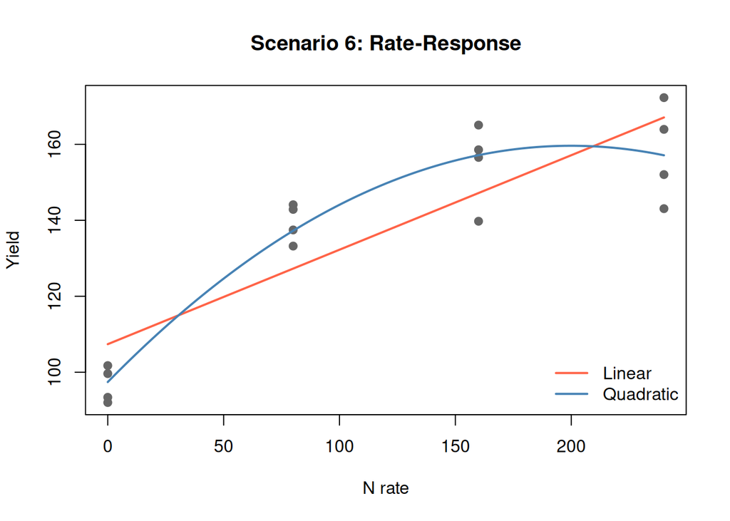

```r
plot(nrate$n_rate, nrate$yield,
     pch = 19,
     col = "grey40",
     xlab = "N rate",
     ylab = "Yield",
     main = "Scenario 6: Rate-Response")
curve(predict(model_linear,
      newdata = data.frame(n_rate = x)),
  add = TRUE,
  col = "tomato",
  lwd = 2)
curve(predict(model_quadratic,
      newdata = data.frame(n_rate = x)),
  add = TRUE,
  col = "steelblue",
  lwd = 2)
legend("bottomright",
   legend = c("Linear", "Quadratic"),
   col = c("tomato", "steelblue"),
   lwd = 2,
   bty = "n")
```

# Scenario 7: Spatial Layers and Inference (Shapefiles and Rasters)

Suppose the question is spatial: where should we apply or adjust management, not just how much change happened on average.

So now we shift from “how much” to “where”.

This takes us back to:

- Module 12: coordinate systems, projections, vector/raster workflows

In spatial analysis, geometry and coordinate reference systems are part of the statistical validity. If layers are mismatched, the map may look fine but be analytically wrong.

This is not a cosmetic issue. It is an inference issue.

Spatial analysis adds one more layer to inference: location itself is information, and nearby observations are often more similar than distant observations.

In practice, this usually combines:

- vector boundaries/management zones
- raster or interpolated surfaces
- extraction/summarization by zone for decision support

So, in practical terms, Module 12 turns model outputs into spatially actionable recommendations.

Now we inspect vector and raster objects separately.

This is where I want you to slow down and verify geometry and extent before trusting any map output.

We start with the vector boundary first because it defines the analysis footprint. Then we move to the raster layer and ask whether its extent and resolution are compatible with that footprint.

```r
field <- st_read("data/field.geojson", quiet = TRUE)
print(field)
```

```
## Simple feature collection with 1 feature and 0 fields
## Geometry type: POLYGON
## Dimension:     XY
## Bounding box:  xmin: -93.77081 ymin: 42.01631 xmax: -93.76722 ymax: 42.01841
## Geodetic CRS:  WGS 84
##                         geometry
## 1 POLYGON ((-93.77081 42.0184...
```

```r
st_bbox(field)
```

```
##      xmin      ymin      xmax      ymax
## -93.77081  42.01631 -93.76722  42.01841
```

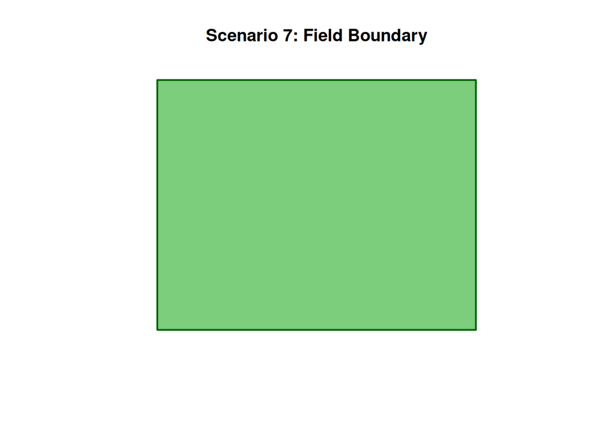

```r
plot(st_geometry(field),
  col = "palegreen3",
  border = "darkgreen",
  lwd = 2,
  main = "Scenario 7: Field Boundary")
```

```r
ndvi <- read_stars("data/example_ndvi.tif")
print(ndvi)
```

```
## stars object with 2 dimensions and 1 attribute
## attribute(s):
##                        Min.   1st Qu.    Median      Mean   3rd Qu.      Max.
## example_ndvi.tif  0.3816743 0.5375135 0.5492938 0.5459545 0.5602355 0.5785804
##                   NA's
## example_ndvi.tif   469
## dimension(s):
##   from to  offset delta                refsys point x/y
## x    1 39  487110    10 WGS 84 / UTM zone 15N FALSE [x]
## y    1 37 4613090   -10 WGS 84 / UTM zone 15N FALSE [y]
```

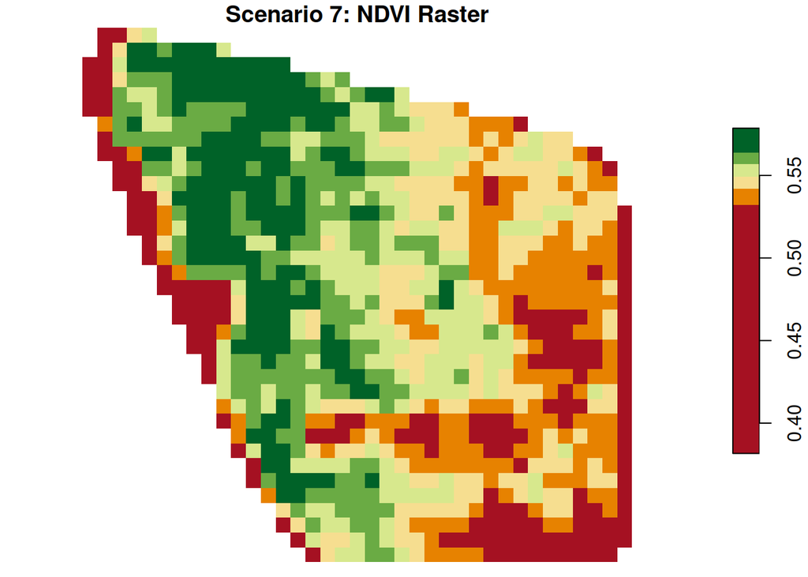

```r
plot(ndvi,
  main = "Scenario 7: NDVI Raster",
  col = hcl.colors(6, palette = "RdYlGn"))
```

# Scenario 8: Yield Prediction (Multiple Linear Regression and other Predictive Models)

Finally, suppose the goal is prediction rather than explanation.

This takes us back to:

- Module 11: multiple predictor modeling and multicollinearity checks
- Module 13: supervised learning, feature-based prediction, and overfitting control

Traditional regression remains powerful when interpretability is a priority. Machine learning becomes useful when relationships are complex and prediction is the primary objective.

In other words, the tool can change, but the discipline cannot.

Machine learning is not a replacement for statistical thinking. It is an extension of the same workflow in more flexible predictive settings.

Regardless of tool, the core discipline is the same:

1. Define target clearly.
2. Validate on unseen data.
3. Report limitations and uncertainty.
4. Avoid overfitting.

If we skip that discipline, high apparent accuracy in-sample can fail in real fields.

So this first chunk prepares an honest train/test split. I keep this step explicit so students can see exactly how we separate model fitting from model evaluation.

```r
county <- read.csv("data/county_environments.csv")

set.seed(20260502)
idx <- sample(seq_len(nrow(model_data)),
              size = floor(0.7 * nrow(model_data)))
```

Now we fit the model on the training split.

This is our in-sample learning step.

```r
model_mlr <- lm(corn ~ ppt + sand + clay + om + sph, data = train_data)
summary(model_mlr)
```

```
##
## Call:
## lm(formula = corn ~ ppt + sand + clay + om + sph, data = train_data)
##
## Residuals:
##     Min      1Q  Median      3Q     Max
## -43.168  -4.635   0.706   7.434  23.018
##
## Coefficients:
##               Estimate Std. Error t value Pr(>|t|)
## (Intercept) -1.803e+02  3.075e+01  -5.865 5.59e-08 ***
## ppt          3.638e-01  2.744e-02  13.258  < 2e-16 ***
## sand        -2.999e-01  1.346e-01  -2.228 0.028050 *
## clay        -1.114e+00  2.939e-01  -3.792 0.000253 ***
## om          -1.848e-02  3.847e-03  -4.805 5.34e-06 ***
## sph          2.328e+01  2.644e+00   8.806 3.54e-14 ***
## ---
## Signif. codes:  0 '***' 0.001 '**' 0.01 '*' 0.05 '.' 0.1 ' ' 1
##
## Residual standard error: 10.96 on 102 degrees of freedom
##   (3 observations deleted due to missingness)
## Multiple R-squared:  0.7271, Adjusted R-squared:  0.7137
## F-statistic: 54.35 on 5 and 102 DF,  p-value: < 2.2e-16
```

[figure not shown]

```r
par(mfrow = c(1, 2))
plot(model_mlr, which = 1)
```

Finally, we evaluate out-of-sample performance.

This is where we test whether the model generalizes.

In agronomic terms, this asks: does performance hold on unseen environments, or did we mostly memorize the training data?

In this final step, we compute predictions, compare observed versus predicted values, and summarize error with RMSE. That gives us a direct decision-oriented check of practical model usefulness.

```r
pred_test <- predict(model_mlr, newdata = test_data)

rmse <- sqrt(mean((test_data$corn - pred_test)^2))

head(data.frame(observed = test_data$corn,
                predicted = pred_test))
```

```
##      observed predicted
## 29   83.21111  82.87714
## 101  88.78421 109.11330
## 165  85.72857 112.03573
## 187  79.03043  94.36284
## 197 109.98000 109.78397
## 300 145.38286 133.09196
```

```r
summary(model_mlr)$adj.r.squared
```

```
## [1] 0.7136987
```

```r
rmse
```

```
## [1] 9.940815
```

If test RMSE is large relative to the variation you can tolerate in practice, the model is not ready for high-stakes recommendations yet.

# Summary

From Modules 00 to 13, the course built a single analytical logic:

- organize data reproducibly
- identify data type and design structure
- choose a model that matches question and assumptions
- diagnose before concluding
- communicate results in agronomic terms

That is the entire workflow we are trying to develop as professionals.

If you have followed all modules, this sequence should feel familiar: question, design, model, diagnostics, interpretation.

Across all of these tools, we are never producing certainty. We are making decisions under variability, incomplete information, and biological complexity. The goal is not perfect prediction. The goal is disciplined reasoning.

So if you remember one thing from Module 14, let it be this:

> Start from the agronomic question, choose the method that respects the data-generating process, and report conclusions with both statistical rigor and biological sense.